# Task18 - Key Examples, perhaps for discussion

Andrew Stein

# Introduction

The idea is to identify cases where AFIR theory doesn’t match SCIM simulation and understand why and build in tests for this.

# Setup and Read Data

```r
source("ams_initialize_script.R")
source("SCIM_calculation.R")
source("ivsc_2cmt_RR_V1.R")
library(RxODE)
model = ivsc_2cmt_RR_KdT0L0()
dirs$rscript_name = "Task18_Collection_Key_Examples.Rmd"
dirs$filename_prefix= str_extract(dirs$rscript_name,"^Task\\d\\d\\w?_")

data_in = read.csv("results/Task16c_data.csv",stringsAsFactors = FALSE)

data = data_in

assumptions = data %>%
  select(id,AFIR_thy,AFIR_sim,SCIM_simplest_thy,SCIM_adhoc_thy,SCIM_sim,starts_with("assumption")) %>%
  arrange(SCIM_sim)
nam = names(assumptions) %>%
  str_replace("^assumption_","")
names(assumptions) = nam
```

# Explore agreement between AFIR theory and SCIM simulation

List of assumptions

- AFIR < 0.30,
- Cavgss >> Ttotss (5x larger)
- Cavgss >> Kss_DT (5x)
- koff_DT > keT (binding faster than elimination)
- koff_TL > 1/30 (not too slow)
- Cavgss >> Kss_DT*Lss/Kss_TL (enough binding)
- Lss/L0 ~ 1 (no accumulation of ligand)

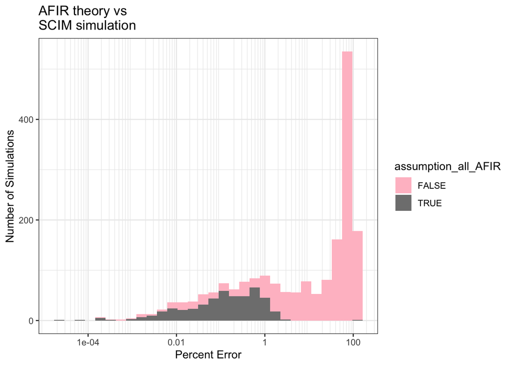

```r
data_plot = data %>%
  filter(dose_mpk <= 100)

g = ggplot(data_plot, aes(AFIR_SCIM_pcterr*100, fill = assumption_all_AFIR))
g = g + geom_histogram()
g = g + xgx_scale_x_log10()
g = g + scale_fill_manual(values = c(`TRUE`="grey50",`FALSE`="pink"))
g = g + labs(x = "Percent Error",
             y = "Number of Simulations")
g = g + ggtitle("AFIR theory vs\nSCIM simulation")
print(g)
```

# Explore agreemnet between SCIM theory and SCIM simulation

List of assumptions. They are similar to the AFIR assumptions, but now we allow for accumulation of Ligand

- SCIM < 30%
- Cavgss >> Ttotss (5x larger)
- Cavgss >> Kss_DT (5x)
- koff_DT > keT (binding faster than elimination)
- koff_TL > 1/30 (not too slow)
- Cavgss >> Kss_DT*Lss/Kss_TL (enough binding)

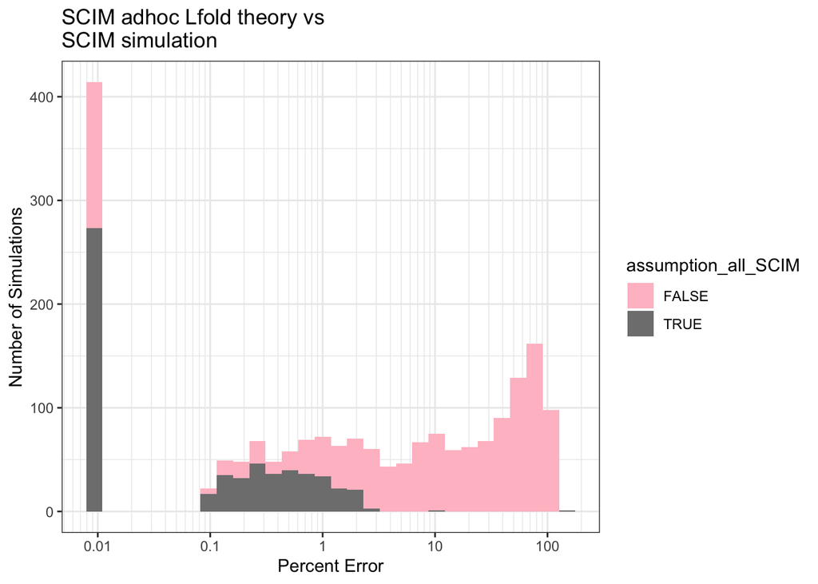

```r
g = ggplot(data_plot, aes(SCIM_SCIM_pcterr*100, fill = assumption_all_SCIM))
g = g + geom_histogram()
g = g + xgx_scale_x_log10()
g = g + scale_fill_manual(values = c(`TRUE`="grey50",`FALSE`="pink"))
g = g + labs(x = "Percent Error",
             y = "Number of Simulations")
g = g + ggtitle("SCIM adhoc Lfold theory vs\nSCIM simulation")
print(g)
```

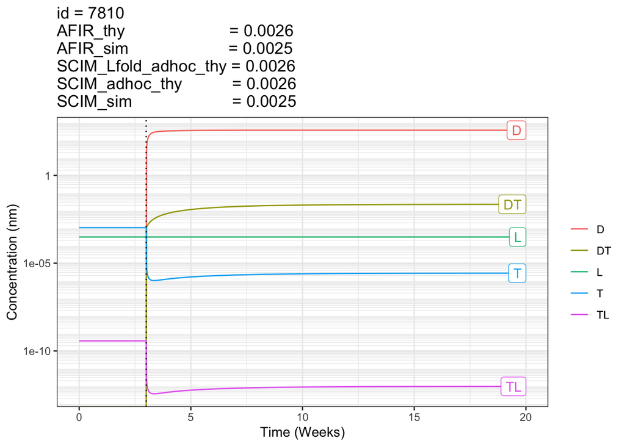

```
## $param
##     id   CL          T0           L0      Kd_DT    Kd_TL  kon_DT   kon_TL
## 1 7810 0.27 0.001058676 0.0003114862 0.03736452 881.2312 6.22378 36.78433
##        keT      keL       keDT     keTL
## 1 1.000486 6.099884 0.04643297 1.602327
##
## $compare
##   type      Dss          T0           L0          TL0     Ttotss
## 1  sim 377.2942 0.001058676 0.0003114862 3.741885e-10 0.02259066
## 2  thy 377.2956 0.001058676 0.0003114862 3.742550e-10 0.02281119
##            Lss         TLss        AFIR        SCIM
## 1 0.0003114863  9.49674e-13 0.002537956 0.002537956
## 2 0.0003114863 -9.90000e+01 0.002553371 0.002559150
##
## $plot
```

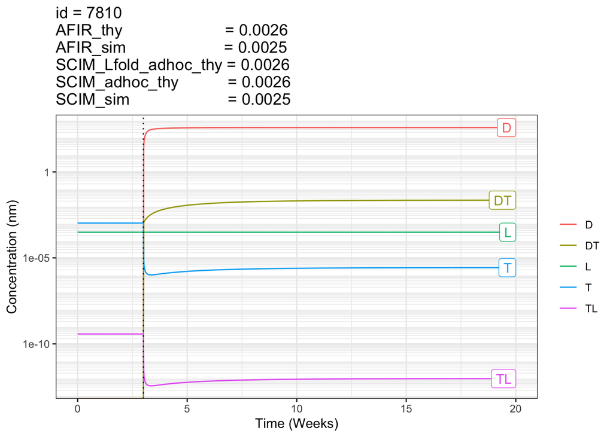

```r
x = data_plot %>%
  filter(assumption_all_SCIM==TRUE) %>%
  arrange(desc(SCIM_SCIM_pcterr))

plot_param(x[1,],model)
```

# Here we check that rounding errors are no longer a problem

### fixed by setting atol and rtol to 1e-12

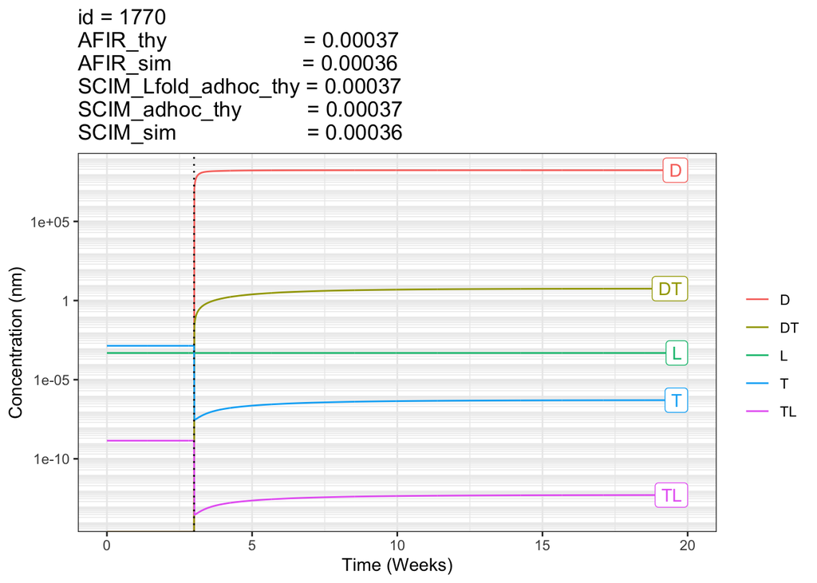

```r
out = plot_param(data %>% filter(id == 1770) ,model)
```

```r
kable(out$param)
```

| id | CL | T0 | L0 | Kd_DT | Kd_TL | kon_DT | kon_TL | keT | keL | keDT | keTL |
| --- | --- | --- | --- | --- | --- | --- | --- | --- | --- | --- | --- |
| 1770 | 0.27 | 0.0013875 | 0.0004875 | 15.49801 | 483.5873 | 74.60397 | 227.1987 | 165.4147 | 100.9446 | 0.0402493 | 65.33294 |

```r
kable(out$compare)
```

| type | Dss | T0 | L0 | TL0 | Ttotss | Lss | TLss | AFIR | SCIM |
| --- | --- | --- | --- | --- | --- | --- | --- | --- | --- |
| sim | 172658296 | 0.0013875 | 0.0004875 | 0 | 5.616604 | 0.0004875 | 0 | 0.0003634 | 0.0003634 |
| thy | 172658330 | 0.0013875 | 0.0004875 | 0 | 5.702159 | 0.0004875 | -99 | 0.0003688 | 0.0003689 |

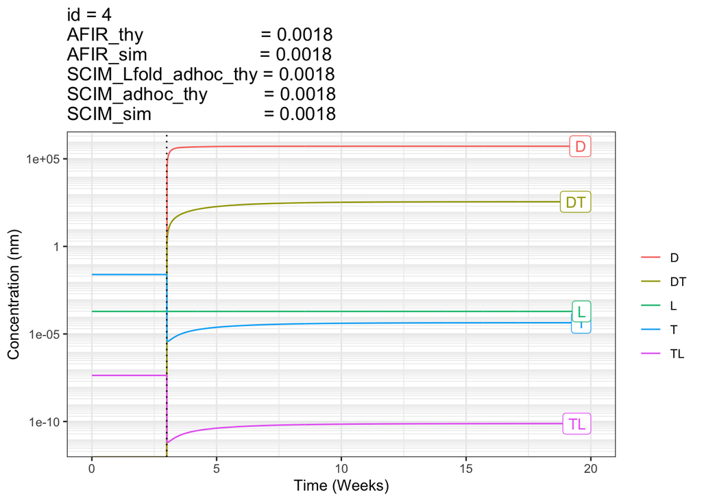

```r
out = plot_param(data %>% filter(id == 4) ,model)
```

```r
kable(out$param)
```

| id | CL | T0 | L0 | Kd_DT | Kd_TL | kon_DT | kon_TL | keT | keL | keDT | keTL |
| --- | --- | --- | --- | --- | --- | --- | --- | --- | --- | --- | --- |
| 4 | 0.27 | 0.0246983 | 0.0001937 | 0.06412 | 107.0408 | 471.2279 | 16.91877 | 768.163 | 134.6917 | 0.0533194 | 78.29303 |

```r
kable(out$compare)
```

| type | Dss | T0 | L0 | TL0 | Ttotss | Lss | TLss | AFIR | SCIM |
| --- | --- | --- | --- | --- | --- | --- | --- | --- | --- |
| sim | 520684.4 | 0.0246983 | 0.0001937 | 0 | 353.8839 | 0.0001937 | 0 | 0.0017676 | 0.0017678 |
| thy | 520708.2 | 0.0246983 | 0.0001937 | 0 | 355.8246 | 0.0001937 | -99 | 0.0017740 | 0.0017774 |

# Make sure to use “correct” Tfold formula

### Fix - For AFIR to predict SCIM, we require Tfold is right

In practice, what would happen in this scenario is that, if we didn’t have ligand data, we would actually predict greater accumulation. And then actually, it might turn out that AFIR would be right! So hmm, maybe the AFIR formula should really have Ttotss/T0 instead of keT/keDT.

This is actually an interesting story to tell, here.

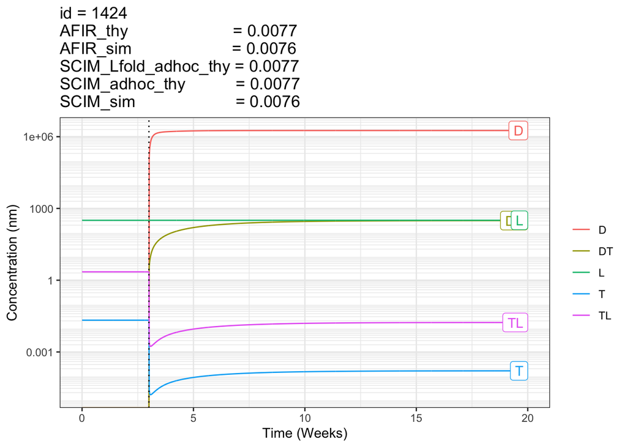

```r
out = plot_param(data %>% filter(id == 1424) ,model)
```

```r
kable(out$param)
```

| id | CL | T0 | L0 | Kd_DT | Kd_TL | kon_DT | kon_TL | keT | keL | keDT | keTL |
| --- | --- | --- | --- | --- | --- | --- | --- | --- | --- | --- | --- |
| 1424 | 0.27 | 0.0213243 | 320.3862 | 0.9501493 | 3.028956 | 1523.764 | 294.7124 | 13.02963 | 23.40251 | 0.0499978 | 6.895892 |

```r
kable(out$compare)
```

| type | Dss | T0 | L0 | TL0 | Ttotss | Lss | TLss | AFIR | SCIM |
| --- | --- | --- | --- | --- | --- | --- | --- | --- | --- |
| sim | 1815239 | 0.0213243 | 320.3862 | 2.238273 | 310.3053 | 321.0408 | 0.017083 | 0.0076167 | 0.0076322 |
| thy | 1815259 | 0.0213243 | 320.3862 | 2.238273 | 314.2683 | 321.0458 | -99.000000 | 0.0076552 | 0.0077297 |

# L accumulates. Causes a mismatch between AFIR and SCIM

### Fix - Need to include an L accumulation factor? Now included in the overleaf document

What if we degine: Lfold = Lss/L0

And then we note that Lss = L0*Lfold

And that Kss_TL = L0*T0/TL0

Then, with a bit of rearranging, we have SCIM = Kd*Lfold/Dss

Is that right? Or do we get a Tfold too? Need to think a bit more.

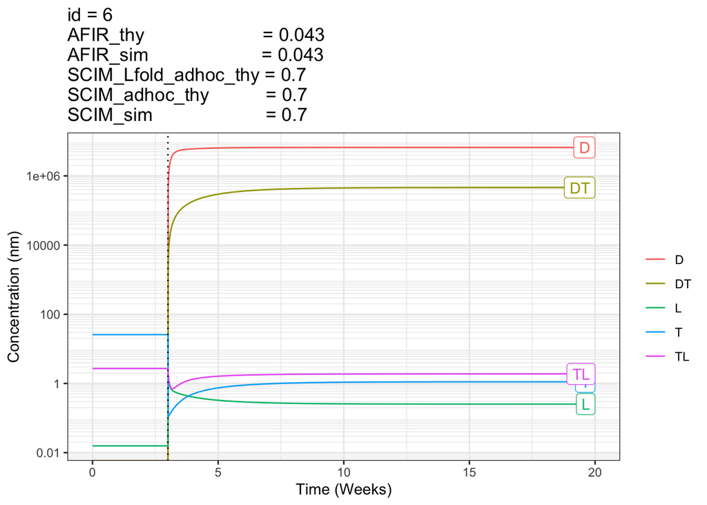

```r
out = plot_param(data %>% filter(id == 6) ,model)
```

```r
kable(out$param)
```

| id | CL | T0 | L0 | Kd_DT | Kd_TL | kon_DT | kon_TL | keT | keL | keDT | keTL |
| --- | --- | --- | --- | --- | --- | --- | --- | --- | --- | --- | --- |
| 6 | 0.27 | 25.81431 | 0.0156664 | 16.08511 | 0.1043041 | 382.9264 | 28.17698 | 1315.46 | 4.397345 | 0.0705785 | 1.274658 |

```r
kable(out$compare)
```

| type | Dss | T0 | L0 | TL0 | Ttotss | Lss | TLss | AFIR | SCIM |
| --- | --- | --- | --- | --- | --- | --- | --- | --- | --- |
| sim | 6639125 | 25.81431 | 0.0156664 | 2.704381 | 460160.5 | 0.2529482 | 1.885789 | 0.0431881 | 0.6973089 |
| thy | 6679741 | 25.81431 | 0.0156664 | 2.704381 | 481182.1 | 0.7995847 | -99.000000 | 0.0429585 | 2.2909031 |

# Case where keTL = 0 and koff_TL is slow

### fix - need the right model, because keTL won’t really be zero

Would need two sets of simulations. One with short time (say just a year) and one with long time, to illustrate the point.